# 03 - Additional Plot Types

```python
reticulate::repl_python()
```

```
Python 3.6.11 (/home/cla/.local/share/r-miniconda/envs/r-reticulate/bin/python)
Reticulate 1.18 REPL -- A Python interpreter in R.
```

```python
import matplotlib.pyplot as plt
import pandas as pd
import seaborn as sns
import numpy as np

grant_file = "/home/cla/Documentos/Vitor/DataCamp/Data-Scientist-with-Python/Datasets/2010 US School Improvement Grants.csv"
df = pd.read_csv(grant_file)

df2 = pd.read_csv("/home/cla/Documentos/Vitor/DataCamp/Data-Scientist-with-Python/Datasets/2018-College-Scorecard-Tuition.csv")

df3 = pd.read_csv("/home/cla/Documentos/Vitor/DataCamp/Data-Scientist-with-Python/Datasets/Washington-DC-Bike-Share.csv")
df3['temp'] = df3.temp/ 1000
df3 = df3[df3['temp'] > 0.1]
```

## **Categorical Plot Types**

**1. Categorical Plot Types**

In the first two chapters of this course, we covered the basics of how to use the Seaborn API for creating and customizing plots using different Seaborn and matplotlib approaches. These chapters provide the foundation for exploring additional plot types. This lesson will focus on the many different categorical plots that Seaborn supports.

**2. Categorical Data**

**3. Plot types - show each observation**

Seaborn breaks categorical data plots into three groups. The first group includes the stripplot() and swarmplot(), which show all the individual observations on the plot.

**4. Plot types - abstract representations**

The second category contains the familiar boxplot(), as well as the violinplot() and lvplot(). These plots show an abstract representation of the categorical data.

**5. Plot types - statistical estimates**

The final group of plots show statistical estimates of the categorical variables. The barplot() and pointplot() contain useful summaries of data. The countplot() shows the number of instances of each observation.

**6. Plots of each observation - stripplot**

```python
reticulate::repl_python()
```

```
Python 3.6.11 (/home/cla/.local/share/r-miniconda/envs/r-reticulate/bin/python)
Reticulate 1.18 REPL -- A Python interpreter in R.
```

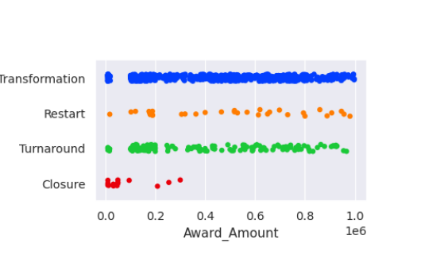

```python
fig, ax = plt.subplots()
_ = fig.tight_layout(pad = 6)

_ = sns.stripplot(data = df, y = 'Model Selected', x = "Award_Amount", jitter = True)

plt.show()
```

```python
plt.clf()
```

**7. Plots of each observation - swarmplot**

We can plot a more sophisticated visualization of all the data using a swarmplot(). This plot uses a complex algorithm to place the observations in a manner where they do not overlap. The downside of this approach is that the swarmplot() does not scale well to large datasets.

```python
reticulate::repl_python()
```

```
Python 3.6.11 (/home/cla/.local/share/r-miniconda/envs/r-reticulate/bin/python)
Reticulate 1.18 REPL -- A Python interpreter in R.
```

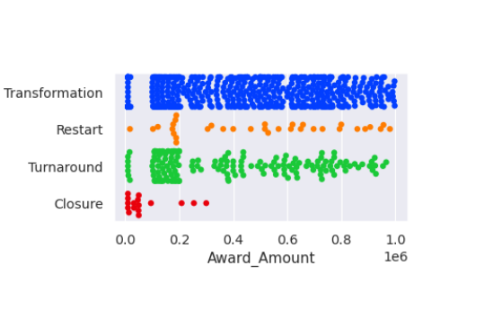

```python
fig, ax = plt.subplots()
_ = fig.tight_layout(pad = 6.5)

_ = sns.swarmplot(data = df, y = 'Model Selected', x = "Award_Amount")
plt.show()
```

```python
plt.clf()
```

**8. Abstract representations - boxplot**

The next category of plots show abstract representations of the data. A boxplot() is the most common of this type. This plot is used to show several measures related to the distribution of data, including the median, upper and lower quartiles, as well as outliers.

```python
reticulate::repl_python()
```

```
Python 3.6.11 (/home/cla/.local/share/r-miniconda/envs/r-reticulate/bin/python)
Reticulate 1.18 REPL -- A Python interpreter in R.
```

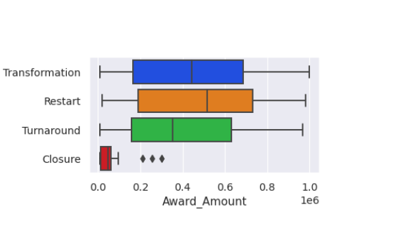

```python
fig, ax = plt.subplots()
_ = fig.tight_layout(pad = 6.5)

_ = sns.boxplot(data = df, y = 'Model Selected', x = "Award_Amount")

plt.show()
```

```python
plt.clf()
```

**9. Abstract representation - violinplot**

The violinplot() is a combination of a kernel density plot and a box plot and can be suitable for providing an alternative view of the distribution of data. Because the plot uses a kernel density calculation it does not show all data points. This can be useful for displaying large datasets but it can be computationally intensive to create.

```python
reticulate::repl_python()
```

```
Python 3.6.11 (/home/cla/.local/share/r-miniconda/envs/r-reticulate/bin/python)
Reticulate 1.18 REPL -- A Python interpreter in R.
```

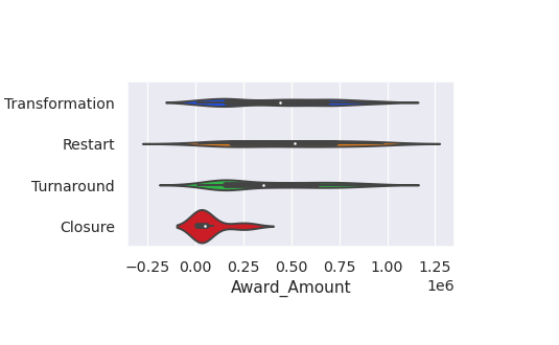

```python
fig, ax = plt.subplots()
_ = fig.tight_layout(pad = 6.5)

_ = sns.violinplot(data = df, y = 'Model Selected', x = "Award_Amount")

plt.show()
```

```python
plt.clf()
```

**10. Abstract representation - lvplot**

The final plot in this grouping is the lvplot(), which stands for Letter Value plot. The API is the same as the boxplot() and violinplot() but can scale more effectively to large datasets. The lvplot() is a hybrid between a boxplot() and violinplot() and is relatively quick to render and easy to interpret.

```python
reticulate::repl_python()
```

```
Python 3.6.11 (/home/cla/.local/share/r-miniconda/envs/r-reticulate/bin/python)
Reticulate 1.18 REPL -- A Python interpreter in R.
```

```python
fig, ax = plt.subplots()
_ = fig.tight_layout(pad = 6.5)

_ = sns.lvplot(data = df, y = 'Model Selected', x = "Award_Amount")
```

```
AttributeError: module 'seaborn' has no attribute 'lvplot'
```

[figure not shown]

```python
plt.show()
```

```python
plt.clf()
```

**11. Statistical estimates - barplot**

The final category of plots are statistical estimates of the data. The barplot() shows an estimate of the value as well as a confidence interval. In this example, we include the hue parameter described in Chapter 1, which provides another useful way for us to look at this categorical data.

```python
reticulate::repl_python()
```

```
Python 3.6.11 (/home/cla/.local/share/r-miniconda/envs/r-reticulate/bin/python)
Reticulate 1.18 REPL -- A Python interpreter in R.
```

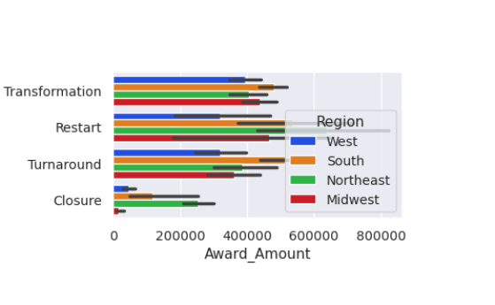

```python
fig, ax = plt.subplots()
_ = fig.tight_layout(pad = 6.5)

_ = sns.barplot(data = df, y = 'Model Selected', x = "Award_Amount", hue = 'Region')

plt.show()
```

```python
plt.clf()
```

**12. Statistical estimates - pointplot**

The pointplot() is similar to the barplot() in that it shows a summary measure and confidence interval. A pointplot() can be very useful for observing how values change across categorical values.

```python
reticulate::repl_python()
```

```
Python 3.6.11 (/home/cla/.local/share/r-miniconda/envs/r-reticulate/bin/python)
Reticulate 1.18 REPL -- A Python interpreter in R.
```

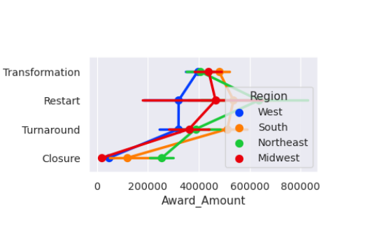

```python
fig, ax = plt.subplots()
_ = fig.tight_layout(pad = 6.5)

_ = sns.pointplot(data = df, y = 'Model Selected', x = "Award_Amount", hue = 'Region')

plt.show()
```

```python
plt.clf()
```

**13. Statistical estimates - countplot**

The final categorical plot is the countplot(), which displays the number of instances of each variable.

```python
reticulate::repl_python()
```

```
Python 3.6.11 (/home/cla/.local/share/r-miniconda/envs/r-reticulate/bin/python)
Reticulate 1.18 REPL -- A Python interpreter in R.
```

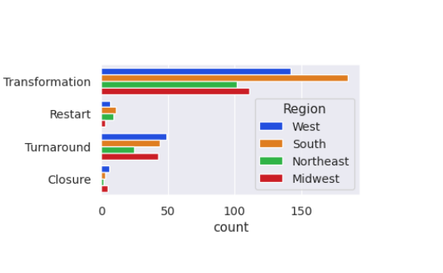

```python
fig, ax = plt.subplots()
_ = fig.tight_layout(pad = 6.5)

_ = sns.countplot(data = df, y = 'Model Selected', hue = 'Region')

plt.show()
```

```python
plt.clf()
```

**14. Let’s practice!**

Now that we have gone through all of the categorical plots available in Seaborn, let’s practice making some of our own.

### **stripplot() and swarmplot()**

Many datasets have categorical data and Seaborn supports several useful plot types for this data. In this example, we will continue to look at the 2010 School Improvement data and segment the data by the types of school improvement models used.

As a refresher, here is the KDE distribution of the Award Amounts:

```python
reticulate::repl_python()
```

```
Python 3.6.11 (/home/cla/.local/share/r-miniconda/envs/r-reticulate/bin/python)
Reticulate 1.18 REPL -- A Python interpreter in R.
```

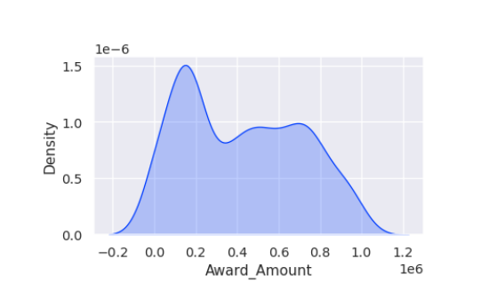

```python
# Read in the DataFrame
grant_file = "/home/cla/Documentos/Vitor/DataCamp/Data-Scientist-with-Python/Datasets/2010 US School Improvement Grants.csv"
df = pd.read_csv(grant_file)
fig, ax = plt.subplots()
_ = fig.tight_layout(pad = 5)

# Create a distplot of the Award Amount
_ = sns.distplot(df['Award_Amount'],
             hist = False,
             rug = False,
             kde_kws = {'shade': True})
# Plot the results
plt.show()
```

```python
plt.clf()
```

While this plot is useful, there is a lot more we can learn by looking at the individual Award_Amounts and how they are distributed among the 4 categories.

**Instructions**

1. Create a `stripplot` of the `Award_Amount` with the `Model Selected` on the y axis with `jitter` enabled.
2. Create a `swarmplot()` of the same data, but also include the hue by Region.

```python
fig, ax = plt.subplots()
_ = fig.tight_layout(pad = 6.5)

# Create the stripplot
_ = sns.stripplot(data = df,
         x = 'Award_Amount',
         y = 'Model Selected',
         jitter = True)

plt.show()
plt.clf()
```

[output not shown]

```python
reticulate::repl_python()
```

```
Python 3.6.11 (/home/cla/.local/share/r-miniconda/envs/r-reticulate/bin/python)
Reticulate 1.18 REPL -- A Python interpreter in R.
```

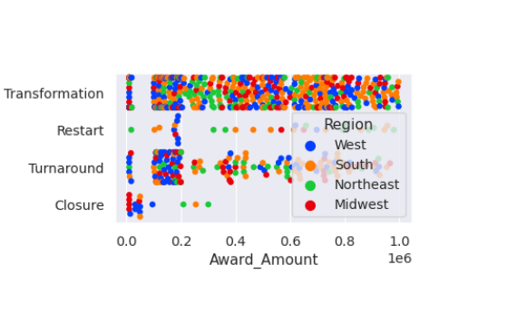

```python
fig, ax = plt.subplots()
_ = fig.tight_layout(pad = 6.5)

# Create and display a swarmplot with hue set to the Region
_ = sns.swarmplot(data = df,
         x = 'Award_Amount',
         y = 'Model Selected',
         hue = 'Region')
plt.show()
```

```python
plt.clf()
```

Categorical plots that show each observation can be very powerful tools for gaining insight into your data.

### **boxplots, violinplots and lvplots**

Seaborn’s categorical plots also support several abstract representations of data. The API for each of these is the same so it is very convenient to try each plot and see if the data lends itself to one over the other.

In this exercise, we will use the color palette options presented in Chapter 2 to show how colors can easily be included in the plots.

**Instructions**

1. Create and display a `boxplot` of the data with `Award_Amount` on the x axis and `Model Selected` on the y axis.
2. Create and display a similar violinplot of the data, but use the husl palette for colors.
3. Create and display an lvplot using the Paired palette and the Region column as the hue.

```python
reticulate::repl_python()
```

```
Python 3.6.11 (/home/cla/.local/share/r-miniconda/envs/r-reticulate/bin/python)
Reticulate 1.18 REPL -- A Python interpreter in R.
```

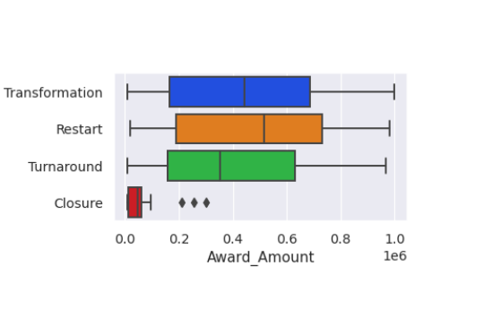

```python
fig, ax = plt.subplots()
_ = fig.tight_layout(pad = 6.5)

# Create a boxplot
_ = sns.boxplot(data = df,
         x = 'Award_Amount',
         y = 'Model Selected')

plt.show()
```

```python
plt.clf()
```

```python
reticulate::repl_python()
```

```
Python 3.6.11 (/home/cla/.local/share/r-miniconda/envs/r-reticulate/bin/python)
Reticulate 1.18 REPL -- A Python interpreter in R.
```

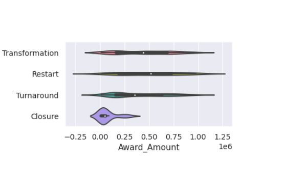

```python
fig, ax = plt.subplots()
_ = fig.tight_layout(pad = 6.5)

# Create a violinplot with the husl palette
_ = sns.violinplot(data = df,
         x = 'Award_Amount',
         y = 'Model Selected',
         palette = 'husl')

plt.show()
```

```python
plt.clf()
```

```python
reticulate::repl_python()
```

```
Python 3.6.11 (/home/cla/.local/share/r-miniconda/envs/r-reticulate/bin/python)
Reticulate 1.18 REPL -- A Python interpreter in R.
```

```python
fig, ax = plt.subplots()
_ = fig.tight_layout(pad = 6.5)

# Create a violinplot with the husl palette
_ = sns.lvplot(data = df,
         x = 'Award_Amount',
         y = 'Model Selected',
         palette = 'Paired',
         hue = 'Region')
```

```
AttributeError: module 'seaborn' has no attribute 'lvplot'
```

[figure not shown]

```python
plt.show()
```

```python
plt.clf()
```

Seaborn’s API makes it very simple to create multiple abstract representations of categorical data.

### **barplots, pointplots and countplots**

The final group of categorical plots are `barplots`, `pointplots` and `countplot` which create statistical summaries of the data. The plots follow a similar API as the other plots and allow further customization for the specific problem at hand.

**Instructions**

1. Create a `countplot` with the `df` dataframe and `Model Selected` on the y axis and the color varying by `Region`.
2. Use a `capsize` in the `pointplot` in order to add caps to the error bars.
3. Create a `barplot` with the same data on the x and y axis and change the color of each bar based on the `Region` column.

```python
reticulate::repl_python()
```

```
Python 3.6.11 (/home/cla/.local/share/r-miniconda/envs/r-reticulate/bin/python)
Reticulate 1.18 REPL -- A Python interpreter in R.
```

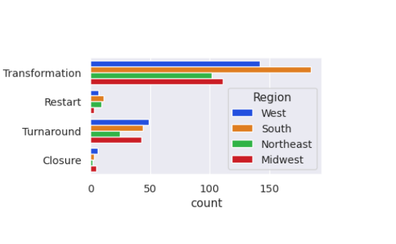

```python
fig, ax = plt.subplots()
_ = fig.tight_layout(pad = 6.5)

# Show a countplot with the number of models used with each region a different color
_ = sns.countplot(data = df,
         y = "Model Selected",
         hue = "Region")

plt.show()
```

```python
plt.clf()
```

```python
reticulate::repl_python()
```

```
Python 3.6.11 (/home/cla/.local/share/r-miniconda/envs/r-reticulate/bin/python)
Reticulate 1.18 REPL -- A Python interpreter in R.
```

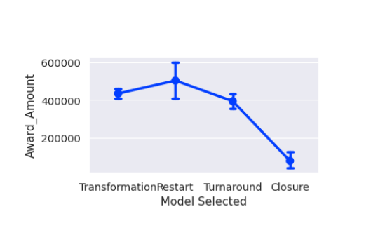

```python
fig, ax = plt.subplots()
_ = fig.tight_layout(pad = 6.5)

# Create a pointplot and include the capsize in order to show caps on the error bars
_ = sns.pointplot(data = df,
         y = 'Award_Amount',
         x = 'Model Selected',
         capsize = 0.1)

plt.show()
```

```python
plt.clf()
```

```python
reticulate::repl_python()
```

```
Python 3.6.11 (/home/cla/.local/share/r-miniconda/envs/r-reticulate/bin/python)
Reticulate 1.18 REPL -- A Python interpreter in R.
```

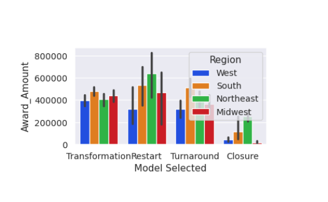

```python
fig, ax = plt.subplots()
_ = fig.tight_layout(pad = 6.5)

# Create a barplot with each Region shown as a different color
_ = sns.barplot(data = df,
         y = 'Award_Amount',
         x = 'Model Selected',
         hue = 'Region')

plt.show()
```

```python
plt.clf()
```

The pointplot and barplot can be useful visualizations for understanding the variations of categorical data.

## **Regression Plots**

**1. Regression Plots**

In Chapter 1, we briefly covered regression plots. Since regression plots are a very important tool in the data scientist’s toolbox, Seaborn has a robust API that supports sophisticated analysis of datasets. In this lesson, we will spend some time looking at regression analysis of bicycle-sharing data from Washington, DC.

**2. Bicycle Dataset**

This dataset contains a summary of bicycle rental activity by day that has been joined with weather information such as temperature, humidity, and overall weather conditions. We can use Seaborn’s regression plotting tools to evaluate the data from multiple perspectives and look for relationships between these numeric variables.

**3. Plotting with regplot()**

Here is a quick summary of the regplot() function. Like most of the Seaborn functions we have reviewed, the function requires the definition of the data and the x and y variables. In this example, we include a unique marker for the observations. Upon first glance, it looks like there is a relationship between temperature and total bike rentals in a day. This intuitively makes sense. People like to bike when the weather is warm.

```python
reticulate::repl_python()
```

```
Python 3.6.11 (/home/cla/.local/share/r-miniconda/envs/r-reticulate/bin/python)
Reticulate 1.18 REPL -- A Python interpreter in R.
```

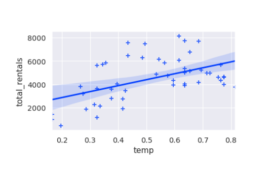

```python
fig, ax =  plt.subplots()
_ = fig.tight_layout(pad = 5)

_ = sns.regplot(data = df3, x = 'temp', y =  'total_rentals', marker = '+')

plt.show()
```

```python
plt.clf()
```

**4. Evaluating regression with residplot()**

The residual plot is a very useful plot for understanding the appropriateness of a regression model. Ideally, the residual values in the plot should be plotted randomly across the horizontal line. In this specific example, the data looks like it might have a slight curve suggesting a nonlinear model might be appropriate.

```python
reticulate::repl_python()
```

```
Python 3.6.11 (/home/cla/.local/share/r-miniconda/envs/r-reticulate/bin/python)
Reticulate 1.18 REPL -- A Python interpreter in R.
```

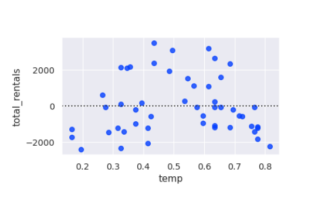

```python
fig, ax =  plt.subplots()
_ = fig.tight_layout(pad = 5)

_ = sns.residplot(data = df3, x = 'temp', y =  'total_rentals')

plt.show()
```

```python
plt.clf()
```

**5. Polynomial regression**

If a value greater than 1 is passed to the order parameter of regplot(), then Seaborn will attempt a polynomial fit using underlying NumPy functions. In this example, Seaborn computes a second order polynomial function for the relationship between temperature and rentals. In this view, it looks like rentals might start to trail off if the weather gets too warm.

```python
reticulate::repl_python()
```

```
Python 3.6.11 (/home/cla/.local/share/r-miniconda/envs/r-reticulate/bin/python)
Reticulate 1.18 REPL -- A Python interpreter in R.
```

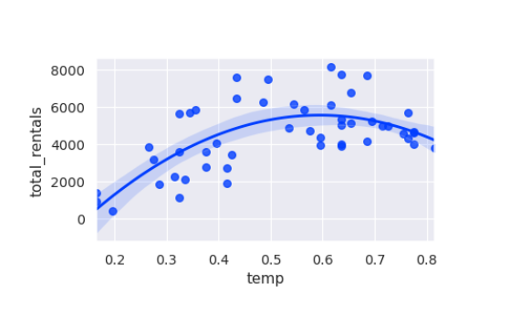

```python
fig, ax =  plt.subplots()
_ = fig.tight_layout(pad = 5)

_ = sns.regplot(data = df3, x = 'temp', y =  'total_rentals', order = 2)

plt.show()
```

```python
plt.clf()
```

**6. residplot with polynomial regression**

The residual plot can interpret the second order polynomial and plot the residual values. In this example, the values are more randomly distributed, so a second order equation is likely more appropriate for this problem.

```python
reticulate::repl_python()
```

```
Python 3.6.11 (/home/cla/.local/share/r-miniconda/envs/r-reticulate/bin/python)
Reticulate 1.18 REPL -- A Python interpreter in R.
```

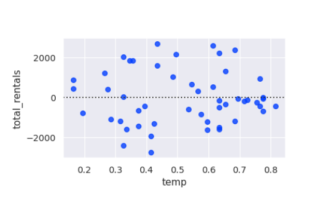

```python
fig, ax =  plt.subplots()
_ = fig.tight_layout(pad = 5)

_ = sns.residplot(data = df3, x = 'temp', y =  'total_rentals', order = 2)

plt.show()
```

```python
plt.clf()
```

**7. Categorical values**

Seaborn also supports regression plots with categorical variables. It might be interesting to see how rentals change over the various months. In this example, using the jitter parameter makes it easier to see the individual distribution of the rental values for each month.

```python
reticulate::repl_python()
```

```
Python 3.6.11 (/home/cla/.local/share/r-miniconda/envs/r-reticulate/bin/python)
Reticulate 1.18 REPL -- A Python interpreter in R.
```

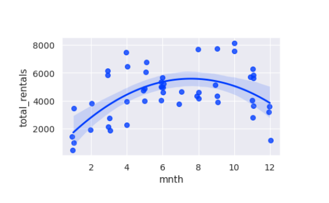

```python
fig, ax =  plt.subplots()
_ = fig.tight_layout(pad = 5)

_ = sns.regplot(data = df3, x = 'mnth', y =  'total_rentals', order = 2, x_jitter = 0.1)

plt.show()
```

```python
plt.clf()
```

**8. Estimators**

In some cases, even with the jitter, it may be difficult to see if there are any trends based on the value of the variable. Using an estimator for the x value can provide another helpful view of the data. This simplified view shows a trend consistent with the seasons in Washington, DC.

```python
reticulate::repl_python()
```

```
Python 3.6.11 (/home/cla/.local/share/r-miniconda/envs/r-reticulate/bin/python)
Reticulate 1.18 REPL -- A Python interpreter in R.
```

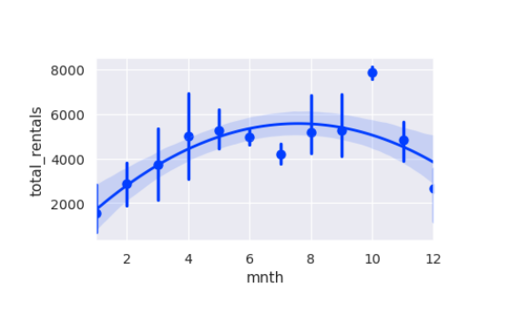

```python
fig, ax =  plt.subplots()
_ = fig.tight_layout(pad = 5)

_ = sns.regplot(data = df3, x = 'mnth', y =  'total_rentals', order = 2, x_estimator = np.mean)

plt.show()
```

```python
plt.clf()
```

**9. Binning the data**

When there are continuous variables, it can be helpful to break them into different bins. In this case, we can divide the temperature into four bins and Seaborn will take care of calculating those bins for us and plotting the results. This is much quicker than trying to use pandas or some other mechanism to create the bins. This shortcut function can help with getting a quick read on continuous data such as temperature.

```python
reticulate::repl_python()
```

```
Python 3.6.11 (/home/cla/.local/share/r-miniconda/envs/r-reticulate/bin/python)
Reticulate 1.18 REPL -- A Python interpreter in R.
```

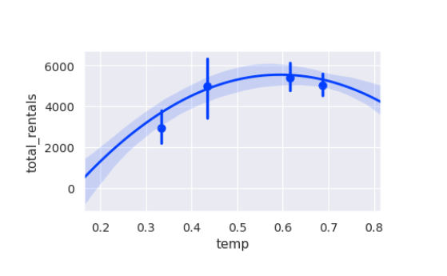

```python
fig, ax =  plt.subplots()
_ = fig.tight_layout(pad = 5)

_ = sns.regplot(data = df3, x = 'temp', y =  'total_rentals', order = 2, x_bins = 4)

plt.show()
```

```python
plt.clf()
```

**10. Let’s practice!**

Seaborn’s regplot() function supports several parameters for creating highly customized regression plots. Now, let’s apply these concepts to some examples.